# Dog Trainer Questionnaire vs Outcome (Fail, Success)

Marinara Marcato

# 1 Introduction

This document tests the hypothesis that there is a difference in behaviours reported in the standardised questionnaire Monash Canine Personality Questionnaire - Revised considering dog’s training outcome.

# 2 Data Exploration

Importing data and converting to adequate data types.

## 2.1 Demographics

The number of dogs in the Dog Trainer Questionnaire dataset.

```
## Number of dogs: 89
```

```
## Training Outcome:
```

```
##
##    Fail Success
##      18      71
```

Analysing categorical demographic data: Sex, Breed. There was only one German Shepherd and two Golden Doodle in the sample, their breeds were relabeled as “Other” for the data analysis.

```
##
##  F  M
## 44 45
```

```
## [1] "Original classes"
```

```
##
## GRxPoodle        GS        LR       LRx     LRxGR
##         2         1        37        16        33
```

```
## [1] "Processed classes"
```

```
##
## Other    LR LRxGR
##     3    37    49
```

Analysing age at assessment and duration of training until withdrawal:

```
## Age at Assessment: Mean 18.34 Standard Deviation 2.6
```

```
##    Min. 1st Qu.  Median    Mean 3rd Qu.    Max.
##   1.143  12.893  14.571  16.079  21.357  31.143
```

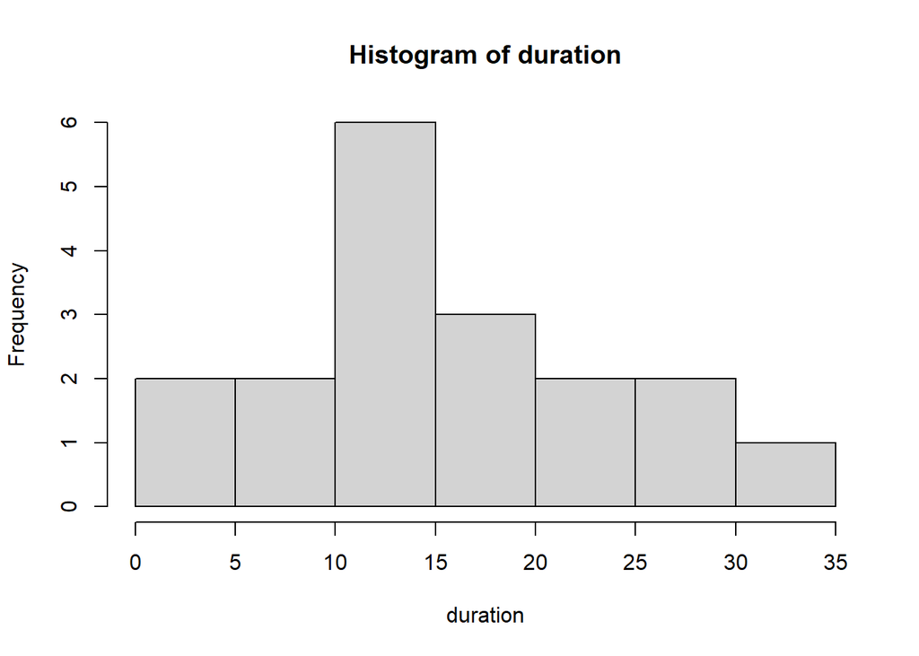

## 2.2 Descriptive Statistics

The MCPQ-R contains 26 items which were scored by the Trainer in a scale from 1 to 6. The questionnaire data are kept as integers, rather than being converted to factors, so the information about the ordering is kept. The descriptive statistics of the questionnaire data shown below are saved as a csv.

```
## Dimension of the dataset including the dependent variable:  89 29
```

```
##                            Min. X1st.Qu. Median      Mean X3rd.Qu. Max.
## Extraversion.Active           1        3      4  3.808989        5    6
## Extraversion.Energetic        1        3      4  3.764045        5    6
## Extraversion.Excitable        1        3      4  3.752809        5    6
## Extraversion.Hyperactive      1        2      3  2.719101        3    6
## Extraversion.Lively           1        3      4  3.617978        4    6
## Extraversion.Restless         1        2      3  3.067416        4    6
## Motivation.Assertive          1        3      3  3.235955        4    6
## Motivation.Determined         1        3      4  3.550562        4    5
## Motivation.Independent        1        2      3  3.247191        4    5
## Motivation.Persevering        1        3      3  3.404494        4    5
## Motivation.Tenacious          1        3      3  3.224719        4    6
## Training.Attentive            1        3      4  3.910112        5    6
## Training.Biddable             2        3      4  3.853933        5    6
## Training.Intelligent          2        4      5  4.494382        5    6
## Training.Obedient             2        3      4  4.067416        5    6
## Training.Reliable             2        3      4  3.797753        5    6
## Training.Trainable            1        4      5  4.370787        5    6
## Amicability.Easy.going        1        3      4  3.685393        5    6
## Amicability.Friendly          1        4      5  4.932584        6    6
## Amicability.Non.aggressive    1        5      6  5.112360        6    6
## Amicability.Relaxed           1        3      4  3.651685        5    6
## Amicability.Sociable          1        4      5  4.674157        5    6
## Neuroticism.Fearful           1        2      2  2.370787        3    6
## Neuroticism.Nervous           1        1      2  2.382022        3    6
## Neuroticism.Submissive        1        2      2  2.617978        3    5
## Neuroticism.Timid             1        2      2  2.505618        3    6
## Sex                          44       45     44 45.000000       44   45
## Breed                         3       37     49  3.000000       37   49
## Outcome                      71       18     71 18.000000       71   18
```

## 2.3 Univariate Logistic Regression

Testing if variables have a statistically significant association with Outcome (Fail, Success). Univariate Logistic Regression models use each feature individually to predict the outcome. Features with a p_value < 0.2 were kept for the multicollinearity analysis and further multivariate logistic regression model.

```
## 'data.frame':    89 obs. of  28 variables:
##  $ Extraversion.Active       : int  5 4 4 3 3 5 3 2 3 4 ...
##  $ Extraversion.Energetic    : int  5 3 4 3 3 5 3 2 3 4 ...
##  $ Extraversion.Excitable    : int  5 5 4 3 3 6 3 2 3 3 ...
##  $ Extraversion.Hyperactive  : int  5 3 3 3 1 6 1 2 2 3 ...
##  $ Extraversion.Lively       : int  5 4 3 3 3 5 3 2 2 4 ...
##  $ Extraversion.Restless     : int  5 3 3 4 2 6 2 2 3 3 ...
##  $ Motivation.Assertive      : int  4 2 3 4 3 5 2 2 2 3 ...
##  $ Motivation.Determined     : int  4 2 3 3 3 4 3 3 3 4 ...
##  $ Motivation.Independent    : int  4 1 3 3 3 3 2 2 2 4 ...
##  $ Motivation.Persevering    : int  5 3 2 3 3 5 3 2 3 4 ...
##  $ Motivation.Tenacious      : int  5 2 2 3 2 5 2 2 2 3 ...
##  $ Training.Attentive        : int  3 5 3 4 4 5 5 4 5 6 ...
##  $ Training.Biddable         : int  4 5 3 3 4 5 5 2 5 5 ...
##  $ Training.Intelligent      : int  5 4 4 4 5 6 5 3 5 6 ...
##  $ Training.Obedient         : int  4 6 4 2 5 6 5 4 5 5 ...
##  $ Training.Reliable         : int  3 4 3 3 5 5 4 2 5 5 ...
##  $ Training.Trainable        : int  4 4 4 4 5 5 4 2 5 6 ...
##  $ Amicability.Easy.going    : int  3 2 2 5 4 1 4 2 3 6 ...
##  $ Amicability.Friendly      : int  5 6 6 5 6 5 6 4 3 6 ...
##  $ Amicability.Non.aggressive: int  6 6 6 6 1 6 1 6 3 6 ...
##  $ Amicability.Relaxed       : int  2 3 2 4 4 2 4 2 3 6 ...
##  $ Amicability.Sociable      : int  5 5 5 4 4 3 4 5 3 6 ...
##  $ Neuroticism.Fearful       : int  2 4 3 1 1 1 1 5 2 2 ...
##  $ Neuroticism.Nervous       : int  2 4 4 1 1 2 1 4 4 2 ...
##  $ Neuroticism.Submissive    : int  2 3 4 1 2 2 2 5 2 2 ...
##  $ Neuroticism.Timid         : int  1 4 4 2 2 1 2 5 2 2 ...
##  $ Sex                       : Factor w/ 2 levels "F","M": 1 2 2 2 2 1 2 1 2 1 ...
##  $ Breed                     : Factor w/ 3 levels "Other","LR","LRxGR": 3 3 3 2 2 2 3 3 2 3 ...
```

```
## [1] "Number of variables considering each level of significance using Logistic test"
```

```
## significant_0.05  significant_0.1  significant_0.2
##               13               16               17
```

```
##                        p_value
## Motivation.Persevering  0.0479
## Training.Attentive      0.0262
## Training.Obedient       0.0194
## Training.Reliable       0.0006
## Training.Trainable      0.0002
## Amicability.Easy.going  0.0017
## Amicability.Friendly    0.0036
## Amicability.Relaxed     0.0021
## Amicability.Sociable    0.0100
## Neuroticism.Fearful     0.0011
## Neuroticism.Nervous     0.0024
## Neuroticism.Submissive  0.0256
## Neuroticism.Timid       0.0060
```

## 2.4 Multicollinearity

The Variance Inflation Factor (VIF) was calculate to assess multicollinearity. VIF = 1 no correlation, 5 < VIF < 10 moderate correlation, VIF > 10 high multicollinearity. VIF larger than 5 or 10 is large and indicate a high level of multicollinearity and should be further processed.

```
##
## Call:
## glm(formula = Outcome ~ ., family = binomial(link = logit), data = data_lr)
##
## Deviance Residuals:
##      Min        1Q    Median        3Q       Max
## -2.91594  -0.48245  -0.22056  -0.08215   2.05349
##
## Coefficients:
##                          Estimate Std. Error z value Pr(>|z|)
## (Intercept)               5.32455    4.19047   1.271   0.2039
## Extraversion.Hyperactive  0.52410    0.41616   1.259   0.2079
## Motivation.Determined     0.10593    0.67607   0.157   0.8755
## Motivation.Persevering   -0.84845    0.58826  -1.442   0.1492
## Training.Attentive        0.13198    0.61376   0.215   0.8297
## Training.Biddable         0.89131    0.71033   1.255   0.2096
## Training.Intelligent     -0.20431    0.54535  -0.375   0.7079
## Training.Obedient         0.19080    0.76481   0.249   0.8030
## Training.Reliable        -0.08339    0.79339  -0.105   0.9163
## Training.Trainable       -1.85760    0.88664  -2.095   0.0362 *
## Amicability.Easy.going   -0.67130    0.53732  -1.249   0.2115
## Amicability.Friendly     -0.78941    0.52617  -1.500   0.1335
## Amicability.Relaxed       0.22821    0.49442   0.462   0.6444
## Amicability.Sociable      0.41174    0.64857   0.635   0.5255
## Neuroticism.Fearful       0.34307    0.58133   0.590   0.5551
## Neuroticism.Nervous      -0.18298    0.60938  -0.300   0.7640
## Neuroticism.Submissive    0.45464    0.69909   0.650   0.5155
## Neuroticism.Timid         0.08041    0.68037   0.118   0.9059
## ---
## Signif. codes:  0 '***' 0.001 '**' 0.01 '*' 0.05 '.' 0.1 ' ' 1
##
## (Dispersion parameter for binomial family taken to be 1)
##
##     Null deviance: 89.623  on 88  degrees of freedom
## Residual deviance: 51.015  on 71  degrees of freedom
## AIC: 87.015
##
## Number of Fisher Scoring iterations: 6
```

```
## Extraversion.Hyperactive    Motivation.Determined   Motivation.Persevering
##                 2.235368                 2.424515                 2.371413
##       Training.Attentive        Training.Biddable     Training.Intelligent
##                 3.372663                 4.249374                 2.452307
##        Training.Obedient        Training.Reliable       Training.Trainable
##                 4.759402                 4.649173                 5.562489
##   Amicability.Easy.going     Amicability.Friendly      Amicability.Relaxed
##                 3.242593                 2.300233                 3.028324
##     Amicability.Sociable      Neuroticism.Fearful      Neuroticism.Nervous
##                 3.360208                 3.337755                 4.670390
##   Neuroticism.Submissive        Neuroticism.Timid
##                 3.389178                 3.878041
```

## 2.6 Visualization

Plotting features selected considering univariate logistic regression pvalue results.

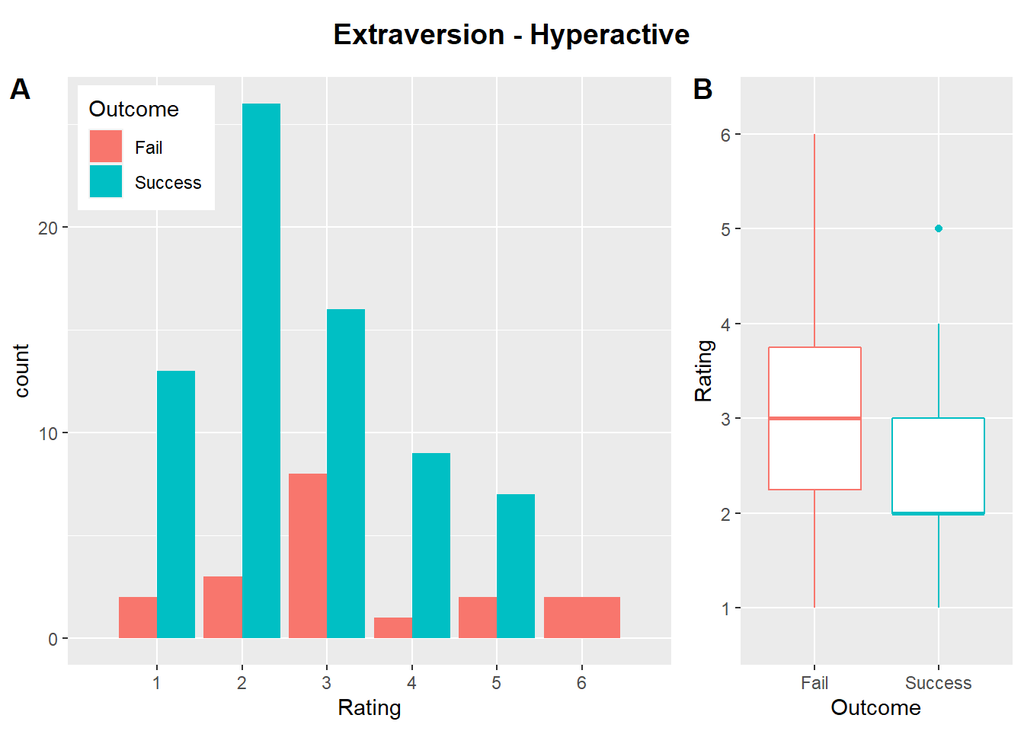

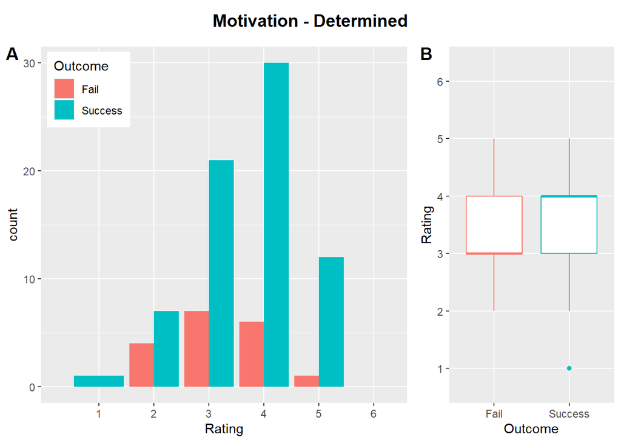

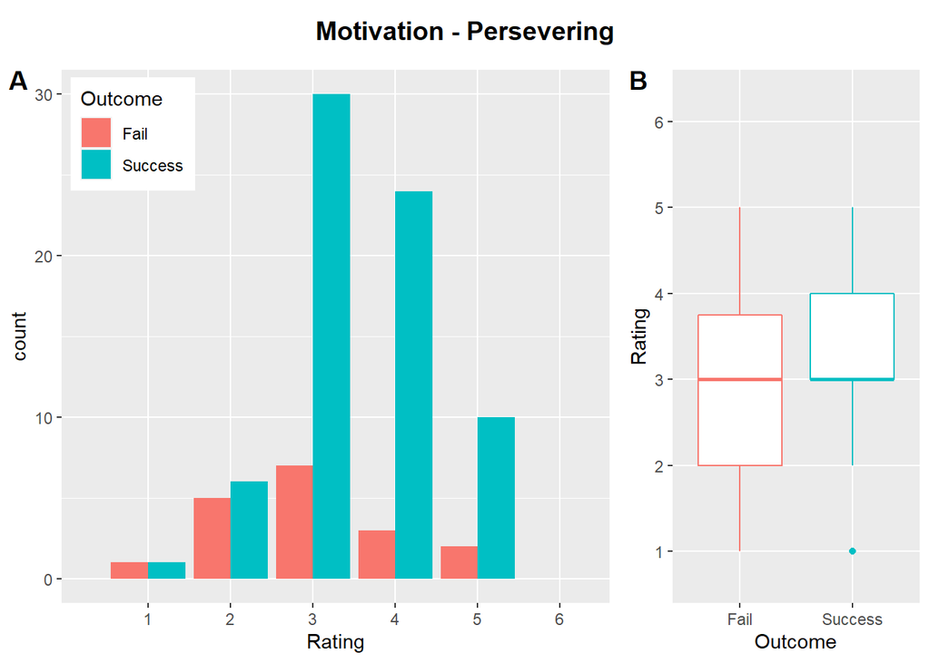

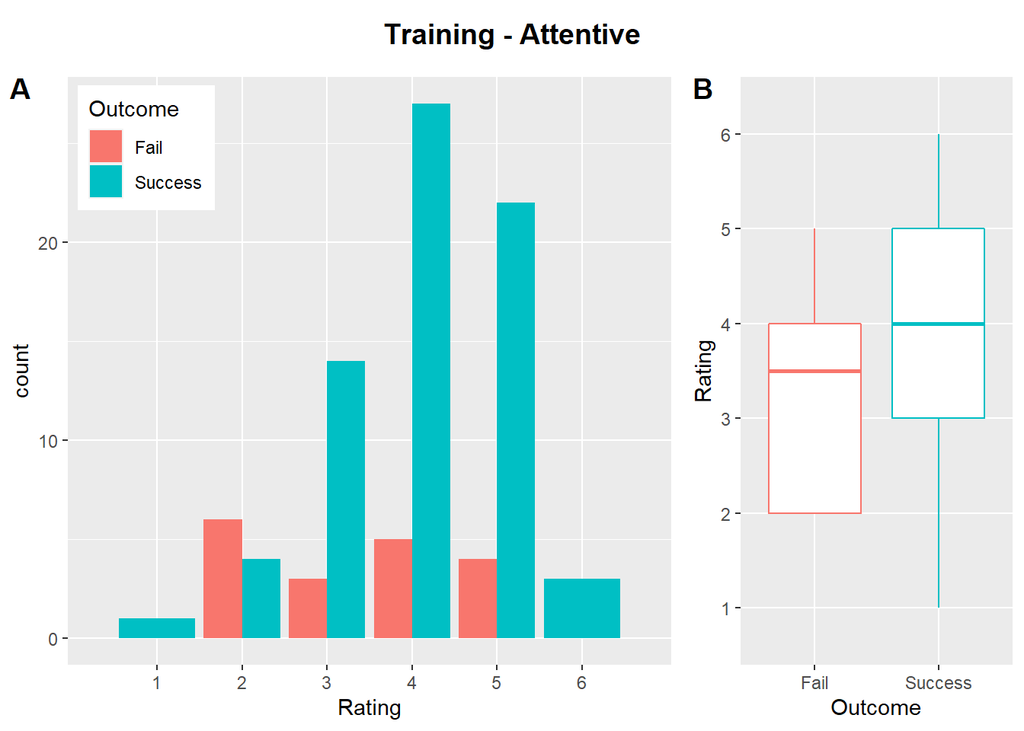

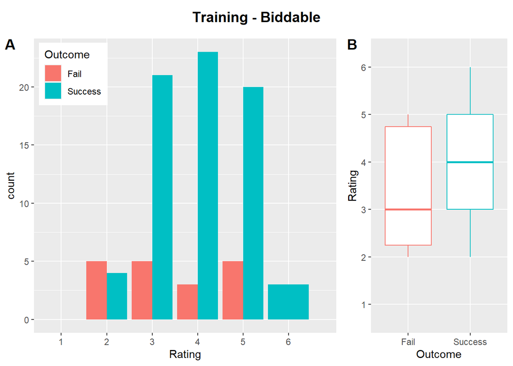

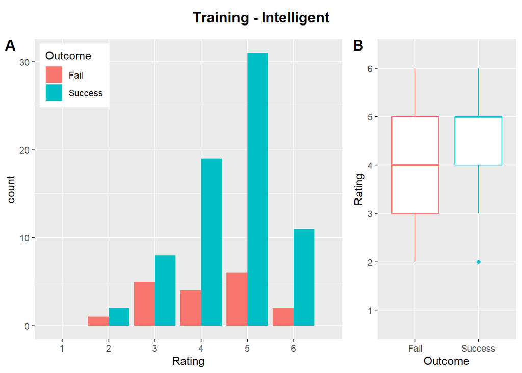

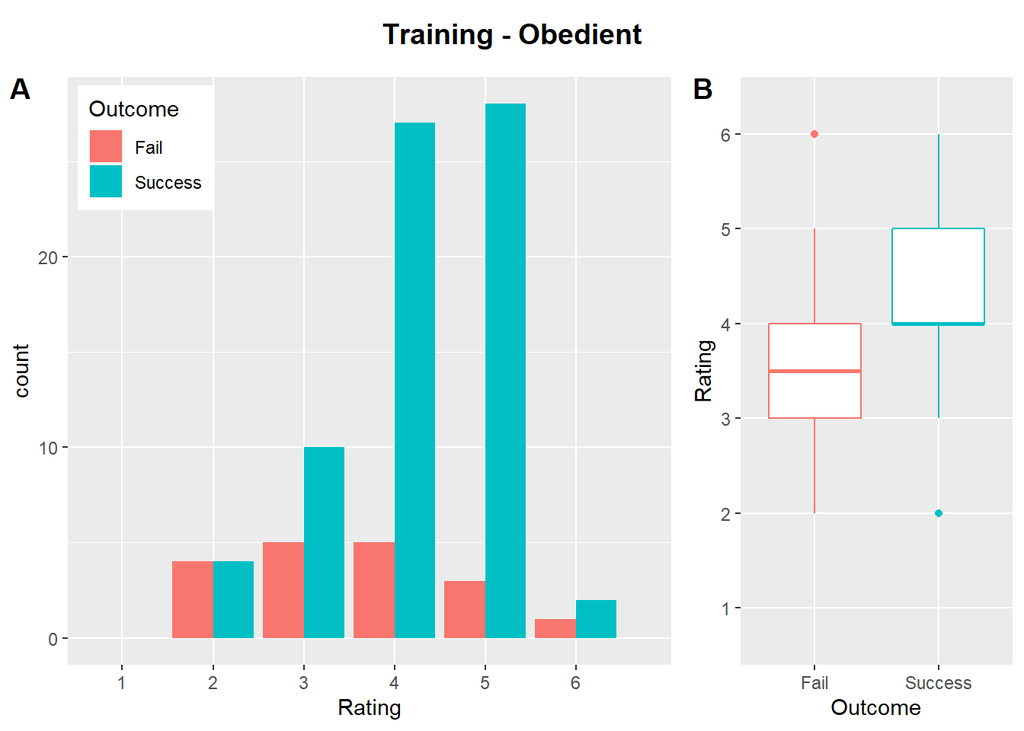

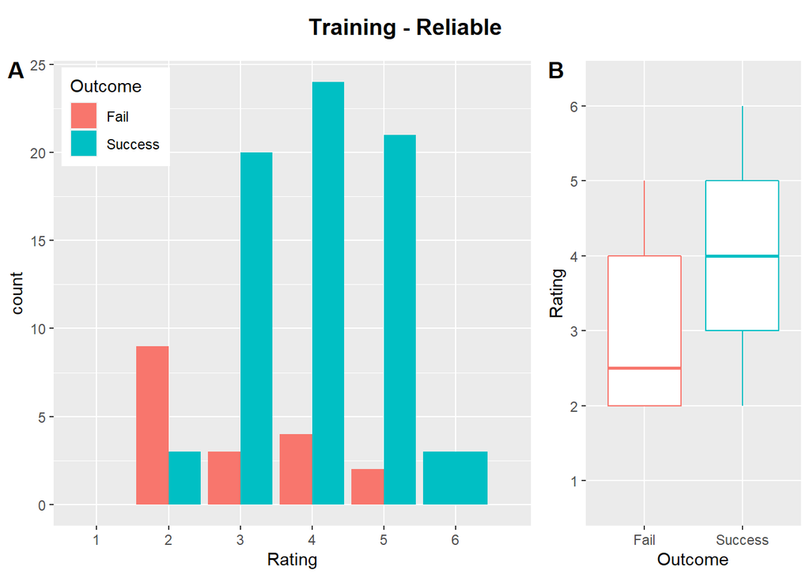

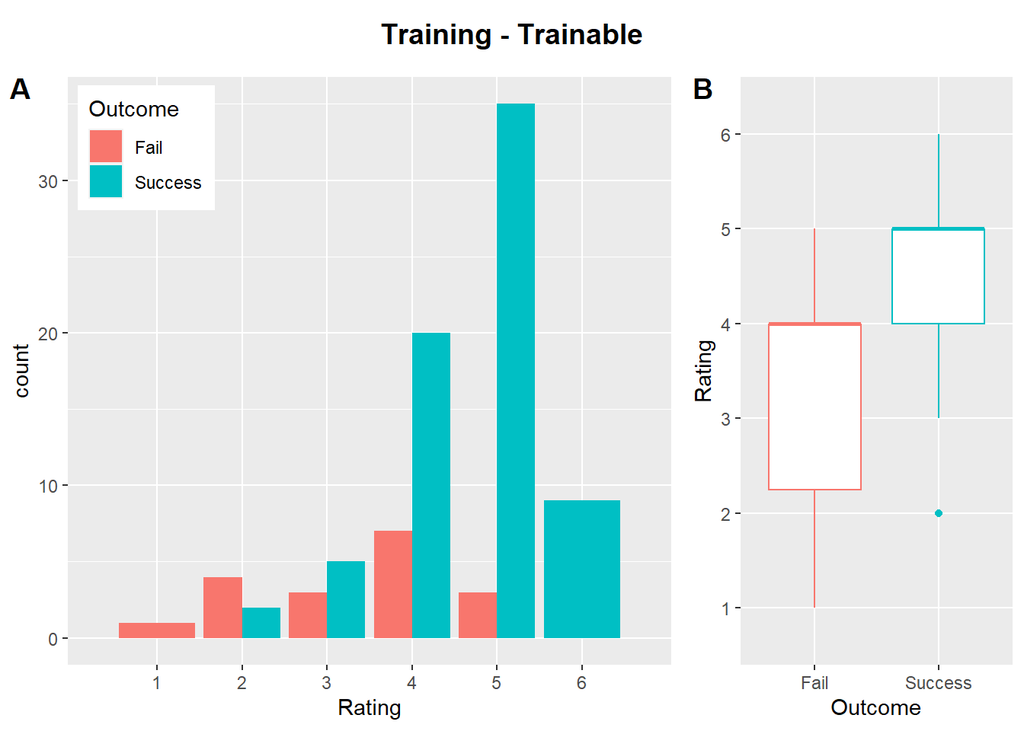

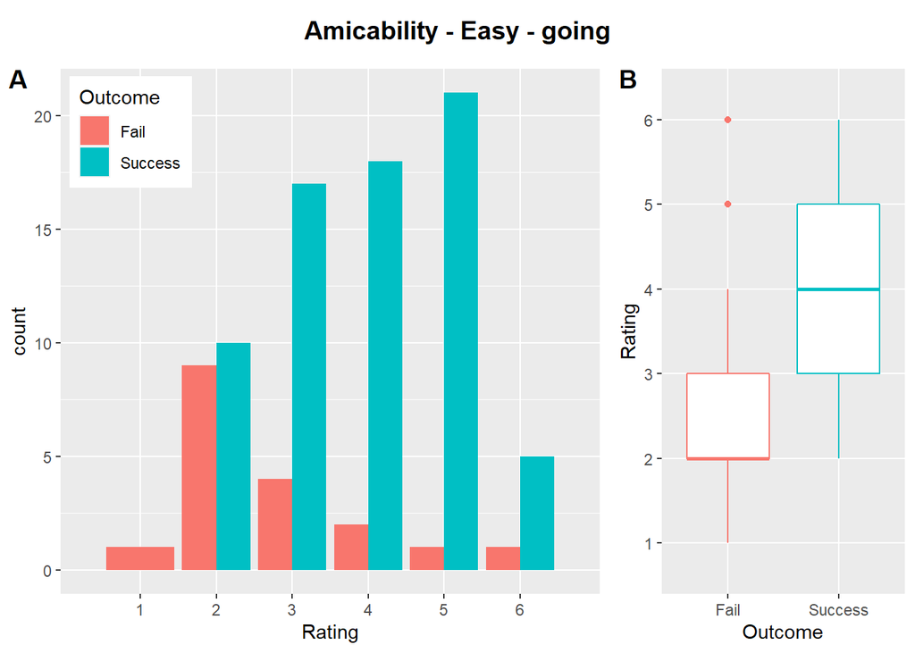

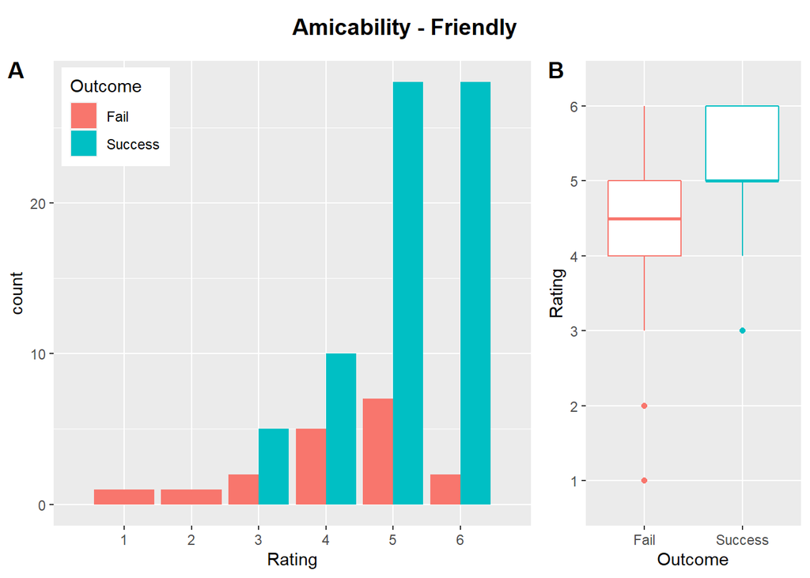

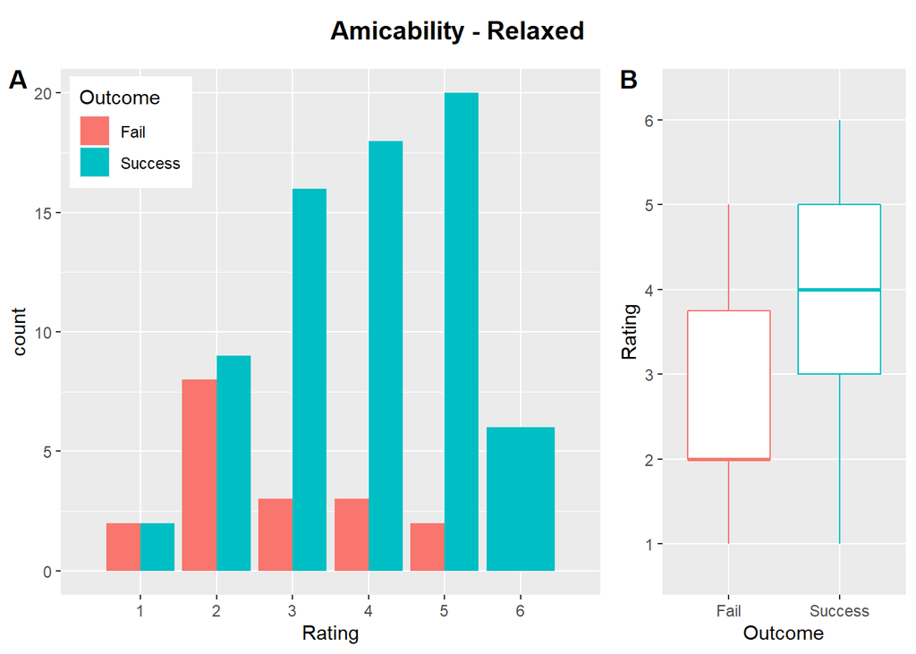

[5 more figures not shown]

# 3 Recursive Feature Elimination (RFE) + Multivariate Logistic Regression (LR)

Selecting only features that had a pvalue < 0.2 in univariate logistic regression analysis and no collinearity issues to estimate Outcome using Logistic Regression. The model also implements Backwards Feature Selection with Recursive Feature Elimination using Leave One Subject Out Cross Validation. [Caret RFE](https://search.r-project.org/CRAN/refmans/caret/html/rfe.html), [RFE Control](https://search.r-project.org/CRAN/refmans/caret/html/rfeControl.html), [Example with RF](https://towardsdatascience.com/effective-feature-selection-recursive-feature-elimination-using-r-148ff998e4f7), [ROC as metric](https://stackoverflow.com/questions/18242692/r-package-caret-rfe-function-how-to-customize-metric-to-use-auc).

```
##
## Recursive feature selection
##
## Outer resampling method: Leave-One-Out Cross-Validation
##
## Resampling performance over subset size:
##
##  Variables    ROC   Sens   Spec Selected
##          0 0.6839 0.9718 0.2778
##          1 0.6839 0.9718 0.2778
##          2 0.6768 0.9296 0.2222
##          3 0.6721 0.9155 0.2222
##          4 0.6315 0.8873 0.2778
##          5 0.7113 0.9296 0.3333
##          6 0.7590 0.9437 0.2778        *
##          7 0.7207 0.9014 0.2778
##          8 0.7379 0.8873 0.2778
##          9 0.7214 0.8592 0.2778
##         10 0.7144 0.9014 0.2778
##         11 0.7113 0.8873 0.2778
##         12 0.7097 0.8592 0.2778
##         13 0.6987 0.8732 0.2778
##         14 0.6721 0.8732 0.2778
##         15 0.6612 0.8732 0.2778
##         16 0.6573 0.8732 0.2778
##         17 0.6557 0.8732 0.2778
##
## The top 5 variables (out of 6):
##    Training.Trainable, Amicability.Friendly, Motivation.Persevering, Training.Biddable, Extraversion.Hyperactive
```

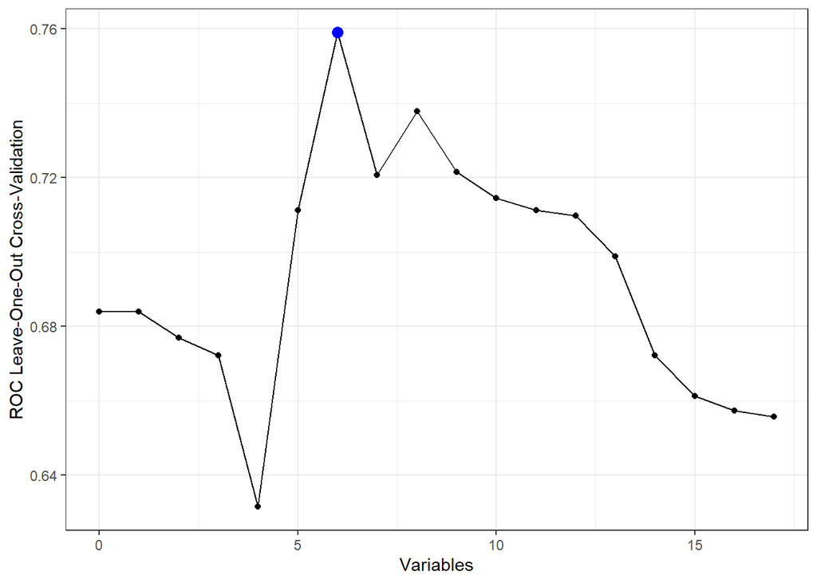

```
## Features in the model that delivered the best ROC Training.Trainable Amicability.Friendly Motivation.Persevering Training.Biddable Extraversion.Hyperactive Amicability.Easy.going
```

```
##
## Call:
## glm(formula = Class ~ ., family = "binomial", data = tmp)
##
## Deviance Residuals:
##     Min       1Q   Median       3Q      Max
## -3.1461  -0.5040  -0.2702  -0.1065   1.9912
##
## Coefficients:
##                          Estimate Std. Error z value Pr(>|z|)
## (Intercept)                8.3112     3.2053   2.593  0.00952 **
## Training.Trainable        -1.4774     0.5454  -2.709  0.00675 **
## Amicability.Friendly      -0.4538     0.3492  -1.300  0.19375
## Motivation.Persevering    -0.8714     0.4181  -2.084  0.03714 *
## Training.Biddable          0.6746     0.5104   1.322  0.18624
## Extraversion.Hyperactive   0.3536     0.3397   1.041  0.29793
## Amicability.Easy.going    -0.6333     0.3614  -1.752  0.07973 .
## ---
## Signif. codes:  0 '***' 0.001 '**' 0.01 '*' 0.05 '.' 0.1 ' ' 1
##
## (Dispersion parameter for binomial family taken to be 1)
##
##     Null deviance: 89.623  on 88  degrees of freedom
## Residual deviance: 55.334  on 82  degrees of freedom
## AIC: 69.334
##
## Number of Fisher Scoring iterations: 6
```

RFE chose 6 variables when optimizing for AUC-ROC, namely: “Training.Trainable”, “Amicability.Friendly”, “Motivation.Persevering”, “Training.Biddable”, “Extraversion.Hyperactive”, “Amicability.Easy.going”. Analysing deviance of full model compared to the null model. Reduction in deviance must be significant (chi-squared test) for the model to be considered a good fit.

```
##
## deviance difference:  34.28983
## df difference:  6
## level of significance:  0.9999941
```

## 3.1 Interpretation

The best Logistic Regression model is used to investigate the effect of each variable on the training outcome.

```
## [1] "Results from the model created"
```

```
##                            Estimate Std. Error   z value    Pr(>|z|)
## (Intercept)               8.3112218  3.2053429  2.592927 0.009516284
## Training.Trainable       -1.4774251  0.5454036 -2.708866 0.006751365
## Amicability.Friendly     -0.4537523  0.3491543 -1.299575 0.193746635
## Motivation.Persevering   -0.8714112  0.4180947 -2.084244 0.037138004
## Training.Biddable         0.6746127  0.5103772  1.321793 0.186237232
## Extraversion.Hyperactive  0.3535964  0.3397102  1.040877 0.297932719
## Amicability.Easy.going   -0.6332834  0.3614136 -1.752240 0.079732504
##                                    OR       2.5 %       97.5 %
## (Intercept)              4069.2816301 14.44593448 4.853586e+06
## Training.Trainable          0.2282246  0.06755537 5.972153e-01
## Amicability.Friendly        0.6352401  0.30944833 1.247527e+00
## Motivation.Persevering      0.4183607  0.16721348 8.932065e-01
## Training.Biddable           1.9632725  0.74843589 5.813144e+00
## Extraversion.Hyperactive    1.4241803  0.74969733 2.920612e+00
## Amicability.Easy.going      0.5308459  0.24580278 1.043686e+00
```

```
## [1] "Training.Trainable"       "Amicability.Friendly"
## [3] "Motivation.Persevering"   "Training.Biddable"
## [5] "Extraversion.Hyperactive" "Amicability.Easy.going"
```

## 3.2 Diagnostics

1. Index plot: residuals vs case number
2. Leverage cases
3. Influence cases

```
##    data.Outcome        phat           h        rpear        rdev            D
## 80         Fail 0.137719673 0.103304399   2.64243144  2.10282393 3.874307e-01
## 14         Fail 0.220038198 0.282240596   2.22227695  2.05391236 8.475176e-01
## 6          Fail 0.301458537 0.222739910   1.72662934  1.75656265 3.874518e-01
## 55         Fail 0.274652626 0.091136884   1.70463698  1.68631506 1.410467e-01
## 23         Fail 0.332650202 0.222185723   1.60599769  1.68230363 3.342416e-01
## 39         Fail 0.311822560 0.086195468   1.55406721  1.59702283 1.104947e-01
## 35         Fail 0.339973393 0.113780406   1.48008815  1.56038760 1.348540e-01
## 69         Fail 0.357555432 0.113849266   1.42394213  1.52354725 1.248984e-01
## 3          Fail 0.438868890 0.233592751   1.29162063  1.46599128 2.290961e-01
## 18         Fail 0.441043027 0.077345916   1.17200443  1.33209384 5.604661e-02
## 63         Fail 0.545059633 0.078087244   0.95150334  1.14739874 3.731447e-02
## 36         Fail 0.619283219 0.280642259   0.92445099  1.15424386 1.456708e-01
## 13         Fail 0.664040149 0.243423550   0.81774917  1.04032546 9.634975e-02
## 85         Fail 0.830588524 0.156721421   0.49180497  0.66350277 2.112818e-02
```

[output cut: 75 more lines]